# Graficando con Turtle

## Graficando con turtle

### 1- Corriendo un script que contiene turtle

Ubicamos el ejercicio dentro de las carpetas compartidas

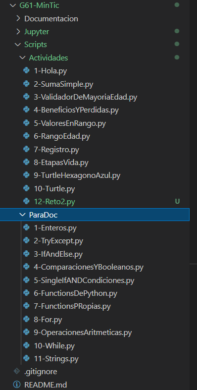

abrimos en el terminal integrado de VS-Code como se explica en el manual de "Ejecutando Scripts de Python" y ejecutamos con el comando python el correspondiente archivo que tiene turtle y damos enter

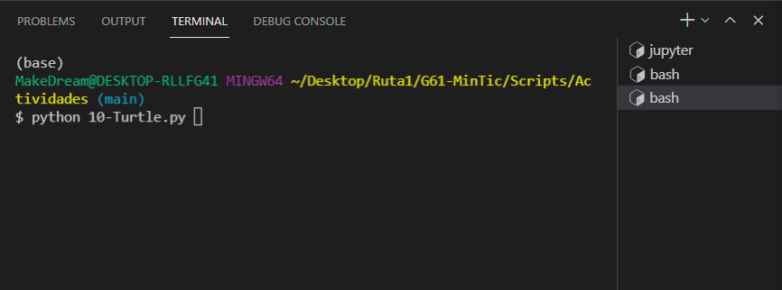

Con el siguiente comando importo todos los scripts de la libreria de turtle, esto me permitira usar todas las funciones de turtle

Las funciones de tortle se encuentra en la pagina

https://docs.python.org/es/3/library/turtle.html

```python
# esto carga el modulpo de turtle y me trae todas las librerias
from turtle import *
```

Este es el archivo base para abrir la pantalla de turtle

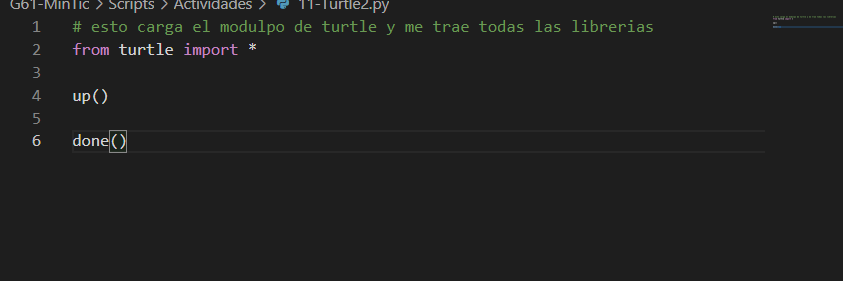

Entonces desde la terminal ejecutamos el archivo base

[figure not shown]

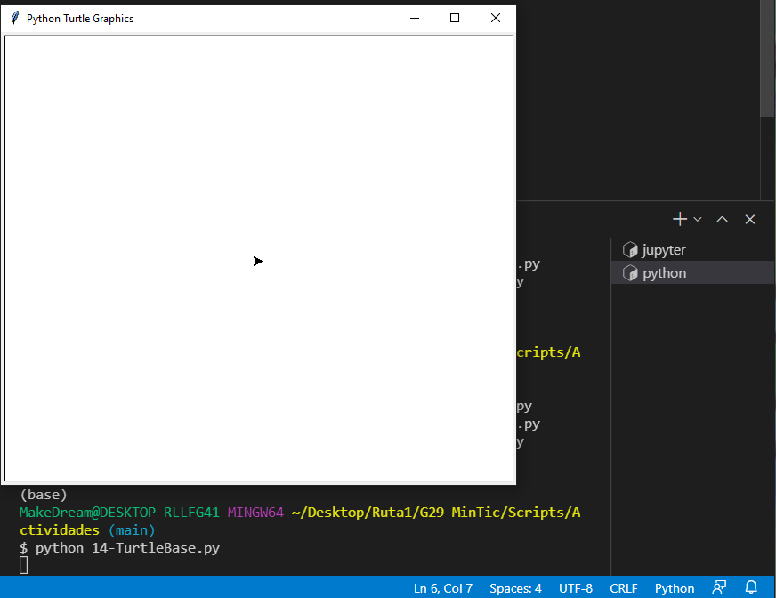

Este archivo base se puede reutilizar para agregar diferentes funciones como en el archivo de actividades 10-Turtle.py o 9-Turtle.py

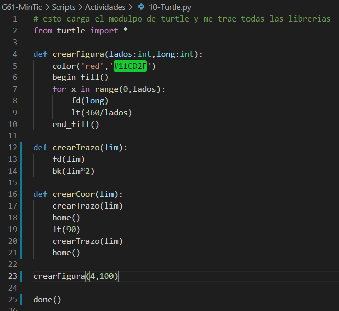

Despues pueden ejecutar el archivo 10-Turtle.py y verificar que a diferencia del archivo base tiene una figura q se representa en el lienzo

[figure not shown]

### 2- Ejecutando turtle desde terminal o jupyter

#### Terminal de Vs-Code

Primero debemos activar una terminal de python, si estamos en VS-Code con el comando python, ptyhon nos mostrara las 3 flechas ">>>" para indicar que nos esta escuchando el interprete de python

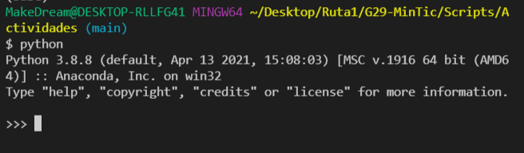

Todo lo que escribamos despues de las >>> lo guardara python en memoria mientras el terminal este activo.

Entonces le enseñaremos todas las funciones de turtle

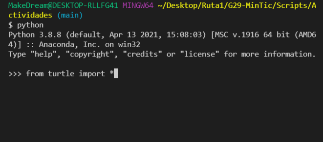

damos enter y ahora simplemnte le damos culquiera de los comandos de la libreria de turtle y vemos como aparece la ventana

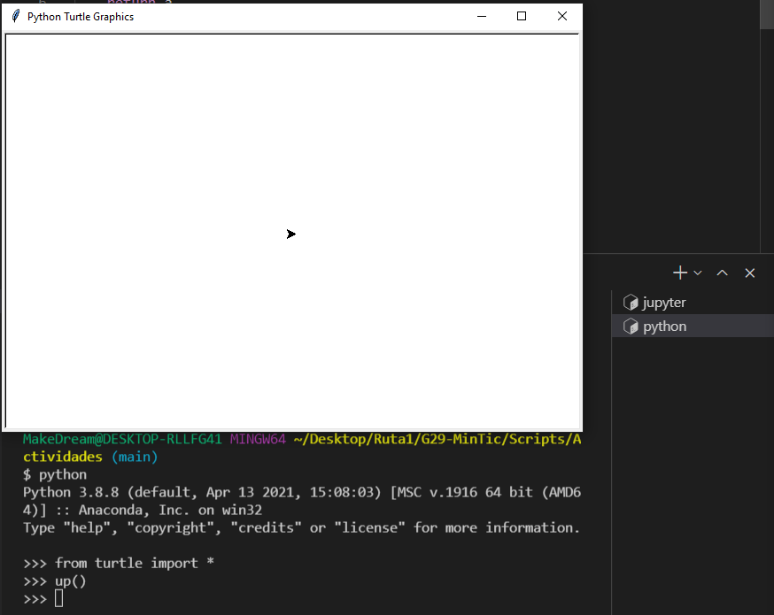

Recuerde que este modo no guarda los procedimientos que se van ejecutando. Usted debe guardarlos en alugn archivo aparte para generar despues sus movimientos personalizados

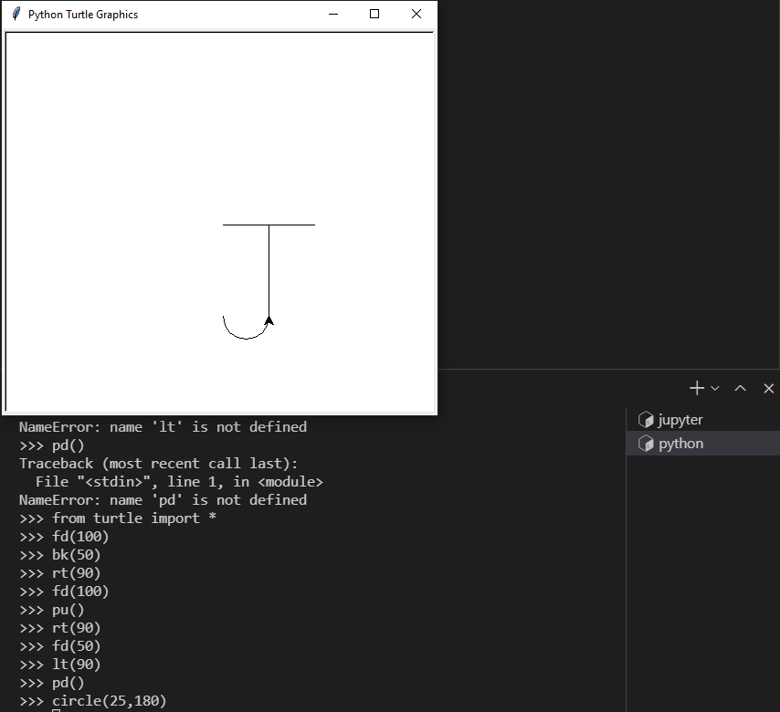

Ya terminado los movimientos de prueba podemos cerra el interprete de python con las techas "ctlr + Z" y despues la tecla "enter"